# Chapter 3 Decomposition

Tyler George

Cornell College  
STA 364 Spring 2025 Block 5

## Setup

```r
library(purrr)
library(gganimate)
library(latex2exp)
library(fpp3)
```

# Transformations and adjustments

## Per capita adjustments

```r
global_economy |>
  filter(Country == "Australia") |>
  autoplot(GDP)
```

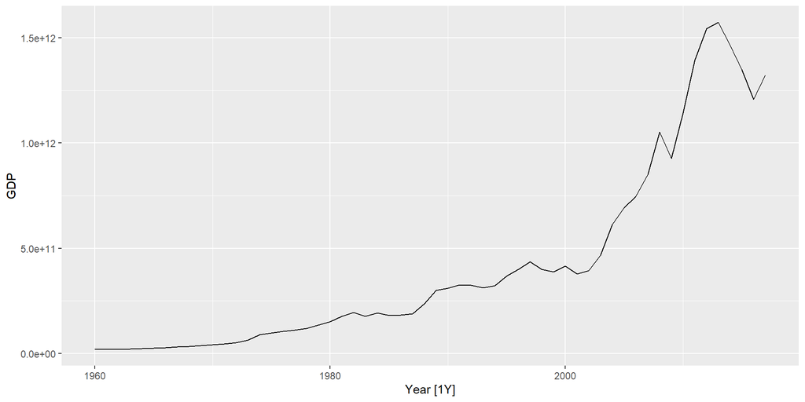

## Per capita adjustments

```r
global_economy |>
  filter(Country == "Australia") |>
  autoplot(GDP / Population)
```

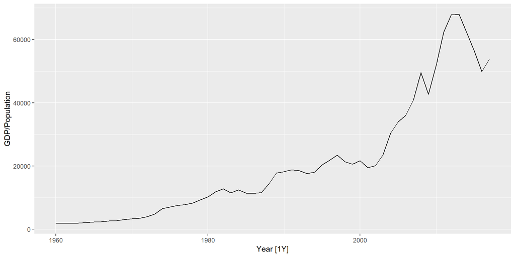

## You Try!

Consider the GDP information in `global_economy`. Plot the GDP per capita for each country over time. Which country has the highest GDP per capita? How has this changed over time? –>

## Inflation adjustments

- Data which are affected by the value of money are best adjusted before modelling.
- For example, the average cost of a new house will have increased over the last few decades due to inflation. A $200,000 house this year is not the same as a $200,000 house twenty years ago.

## Inflation adjustments

- To make these adjustments, a price index is used. If $z_t$ denotes the price index and $y_t$ denotes the original house price in year $t$, then

$$x_t=y_t/z_t \cdot z_{2000}$$

gives the adjusted house price at year 2000 dollar values.

- Price indexes are often constructed by government agencies. For consumer goods, a common price index is the Consumer Price Index (or CPI).

## Inflation adjustments

- Code
- Plot

```r
aus_newspaper_retail <- readr::read_csv('data/aus_newspaper_retail.csv')
# Turnover: Retail turnover in $Million AUD

aus_newspaper_retail <- aus_newspaper_retail |>
  select(Year,Turnover,name) |> # Picks out these 3 columns/variables
  group_by(Year,name) |> # Tells are to now calculate by groups by year and name
  summarise(sum_Turnover = sum(Turnover))|> #adds up Turnover for each year and name combination
  as_tsibble(index = Year, key = "name") # Converts to time series

aus_newspaper_retail |> autoplot(sum_Turnover) +
  facet_grid(name ~ ., scales = "free_y") + # This will make a grid of plots
    # with name used to break into multiple plots along the y direction
  labs(title = "Turnover: Australian print media industry", y = "$AU")
```

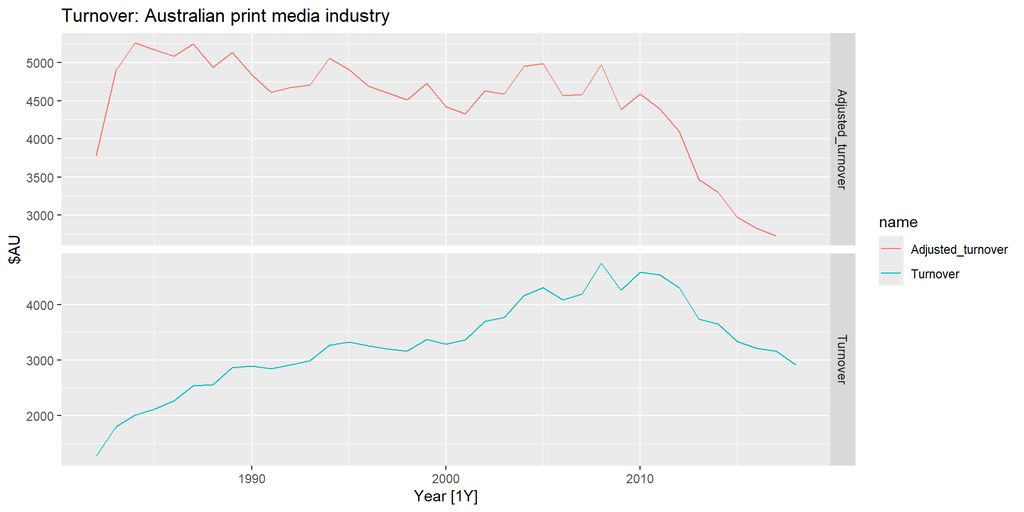

## Mathematical transformations

If the data show different variation at different levels of the series, then a transformation can be useful.

Denote original observations as $y_1,\dots,y_T$ and transformed observations as $w_1, \dots, w_T$.

| Function |  | Impact |
| --- | --- | --- |
| Square root | $w_t = \sqrt{y_t}$ | $\downarrow$ |
| Cube root | $w_t = \sqrt[3]{y_t}$ | Increasing |
| Logarithm | $w_t = \log(y_t)$ | strength |

Logarithms, in particular, are useful because they are more interpretable: changes in a log value are **relative (percent) changes on the original scale**.

## Mathematical transformations (1/4)

```r
food <- aus_retail |>
  filter(Industry == "Food retailing") |>
  summarise(Turnover = sum(Turnover))
```

[figure not shown]

## Mathematical transformations (2/4)

```r
food |> autoplot(sqrt(Turnover)) +
  labs(y = "Square root turnover")
```

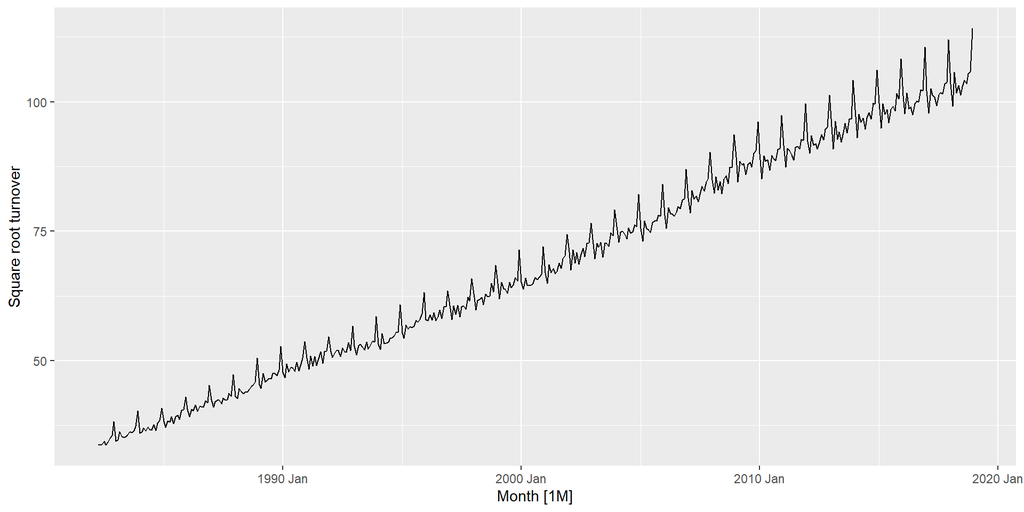

## Mathematical transformations (3/4)

```r
food |> autoplot(Turnover^(1/3)) +
  labs(y = "Cube root turnover")
```

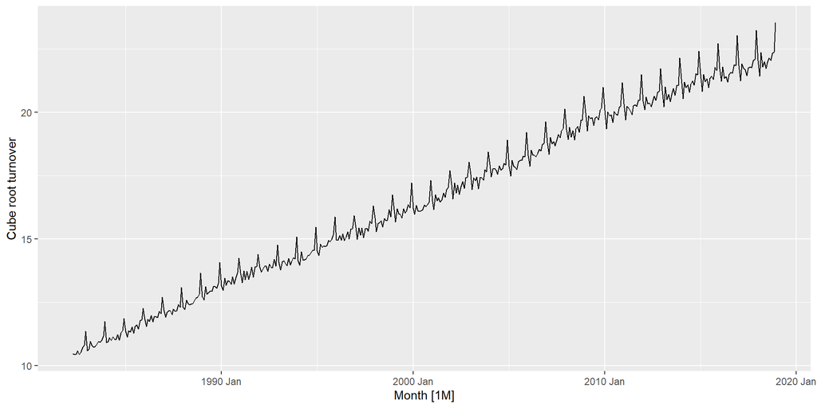

## Mathematical transformations (4/4)

```r
food |> autoplot(log(Turnover)) +
  labs(y = "Log turnover")
```

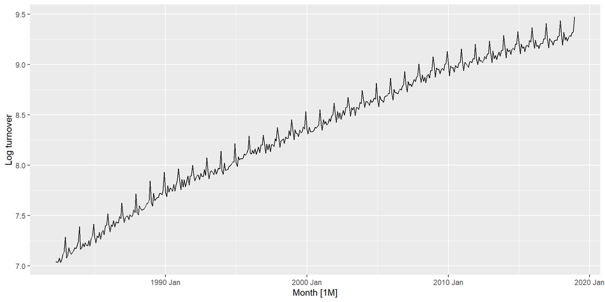

(log here is the natural log, base $e$)